# Baseline Study for the Tuungane Health and Conservation Project

Social Assessment of Lake Tanganyika Households

Sustain East Africa

November 2024

# List of Tables

- 1 Proportion of household heads born in the ward
- 2 Percentage (%) estimates of the Poverty Probability Index (PPI) for households
- 3 Water treatment in the dry season at village level (%)
- 4 Main water source in the dry season at village level (%)
- 5 Sanitation facilities at village level (%)
- 6 Handwashing at village level (%)
- 7 Asset ownership at village level (%)
- 8 BMU awareness and participation at village level (%)
- 9 Conflict of interest and/or power struggle between village leaders and BMU (%)
- 10 Access rights, security, and decision making around fisheries resources at village level (%)
- 11 Awareness and acceptance of fish reserves at village level (%)
- 12 Group membership of fishers at village level (%)
- 13 Group membership of fishers at village level (%)
- 14 Group membership of fish processors at village level (%)

# List of Figures

- 1 Map of lake Tanganyika with sample sizes from each locations
- 2 Population pyramid
- 3 Self-assessment of the ability to meet daily needs at village level
- 4 Type of fishing boats used at village level
- 5 Relative importance of different species at village level
- 6 Main type of water treatment in the dry season
- 7 Main source of water in the dry season
- 8 Household item ownership
- 9 Proportion of households that borrowed money in the last year at village level
- 10 Purpose of the loan
- 11 Source of loans
- 12 Reason for not having borrowed any money in the previous year
- 13 Household membership of a COCOBA, SACCO, or FICO at village level (%)
- 14 Mobile phone usage for financial transactions at village level (%)
- 15 Household participation in BMU activities over the past 12 months at village level (%)
- 16 Household awareness of BMUs at village level (%)
- 17 BMU membership at village level (%)
- 18 BMU membership at village level (%)
- 19 An indication of frequency for BMU activities
- 20 Do you think the BMU has good leaders?
- 21 Were BMU leaders elected or chosen fairly?
- 22 Were BMU leaders elected or chosen fairly?
- 23 Self-assessment of fisheries resource management over the past five years
- 24 Satisfaction with involvement in decision-making around fisheries resources?
- 25 An indication of the relationship with fisheries extension officers
- 26 At the moment, do you think the current number of fish in the lake is sufficient to meet the fishing, food, and livelihood needs of the community?
- 27 In the future, do you think there will be sufficient fish for the communities
- 28 Type of fishing gear used at village level (%)
- 29 Seasonal targeting of fish species over the past five years
- 30 Highest sale prices (TSh) of fish species over the past five years
- 31 Lowest sale prices (TSh) of fish species over the past five years
- 32 Satisfaction levels of fishers
- 33 Do you think BMUs are helpful to improving your fishing practices?
- 34 Do you think your current activities are likely to support your needs over the long term (next 5 - 10 years) ?
- 35 Forms of fish trading
- 36 Seasonal trading of fish species over the past five years
- 37 Highest sale prices (TSh) of fish species over the past five years for fish traders
- 38 Highest sale prices (TSh) of fish species over the past five years for fish traders
- 39 Satisfaction of fish traders
- 40 Do you think your current trading activities are likely to support your needs over the long term (next 5 - 10 years) ?
- 41 Processing form at village level (%)
- 42 Processing equipment at village level (%)
- 43 Seasonal processing of fish species over the past five years
- 44 Highest sale prices (TSh) of fish species over the past five years for fish processors
- 45 Highest sale prices (TSh) of fish species over the past five years for fish processors
- 46 Satisfaction of fish traders
- 47 Do you think your current processing activities are likely to support your needs over the long term (next 5 - 10 years) ?

### Acknowledgements

# Summary

# Introduction

## General Household Information

Household sample sizes across villages along the lake Tanganyika shoreline.

[figure not shown]

Figure 1: Map of lake Tanganyika with sample sizes from each locations

Population Pyramid

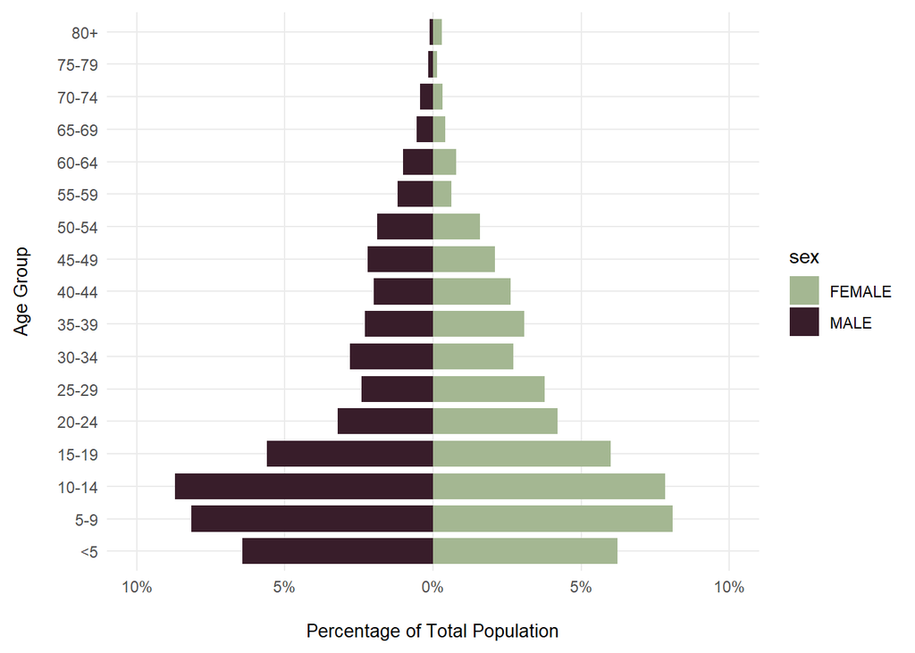

Figure 2: Population pyramid

Table 1: Proportion of household heads born in the ward

| Village | Yes | No | Average years spent if not born |
| --- | --- | --- | --- |
| Isasa | 56.4% | 43.6% | 18.5 |
| Izinga | 18.2% | 81.8% | 26.4 |
| Kala | 10.5% | 89.5% | 21.0 |
| Kalungu | 48.3% | 51.7% | 18.2 |
| Katenge | 53.3% | 46.7% | 25.4 |
| Kichangani | 57.8% | 42.2% | 22.0 |
| Kilambo cha Mkolechi | 31.6% | 68.4% | 18.2 |
| Kipili | 25% | 75% | 26.9 |
| Kizumbi | 22.6% | 77.4% | 21.4 |
| Lyapinda | 38.5% | 61.5% | 22.9 |
| Majengo Mapya | 13.8% | 86.2% | 6.5 |
| Manda Kerenge | 28.7% | 71.3% | 20.5 |
| Manda Uhuru | 10.5% | 89.5% | 28.5 |
| Mkinga | 30.6% | 69.4% | 22.9 |
| Mpasa | 19.5% | 80.5% | 23.1 |
| Mtakuja | 32.7% | 67.3% | 31.5 |
| Mwinza | 12.8% | 87.2% | 27.6 |
| Ng'anga | 16.7% | 83.3% | 29.7 |
| Ntanganyika | 36.1% | 63.9% | 20.5 |
| Tundu | 25% | 75% | 19.6 |
| Wampembe | 18.6% | 81.4% | 19.7 |

## Poverty Probability Index

Table 2: Percentage (%) estimates of the Poverty Probability Index (PPI) for households

| Category | Upper National Poverty Line | Lower National Poverty Line | Extreme Poverty Line |
| --- | --- | --- | --- |
| Overall | 63.6 | 58.2 | 25.6 |
| Male | 65.7 | 60.1 | 26.5 |
| Female | 56.3 | 52.1 | 22.4 |
| Youth | 61.5 | 55.7 | 22.8 |

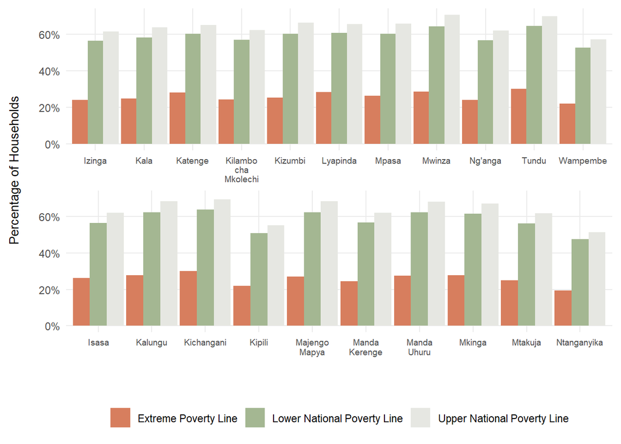

# Quantitative Analysis

## Livelihoods

### Household welfare self-assessment

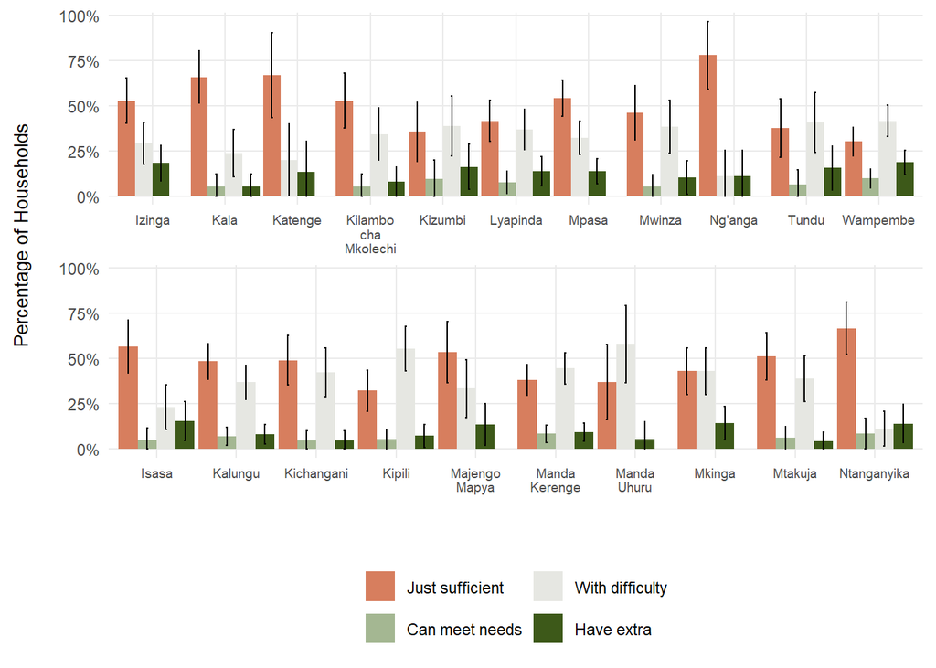

Figure 3: Self-assessment of the ability to meet daily needs at village level

### Fishing

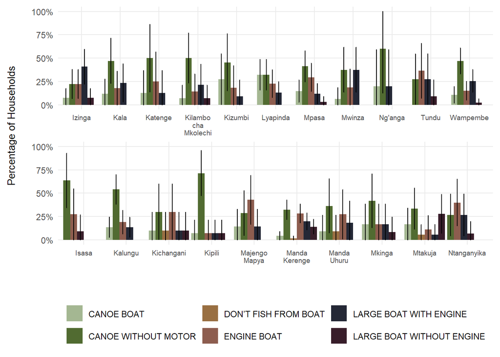

Figure 4: Type of fishing boats used at village level

Relative importance of different species at village level

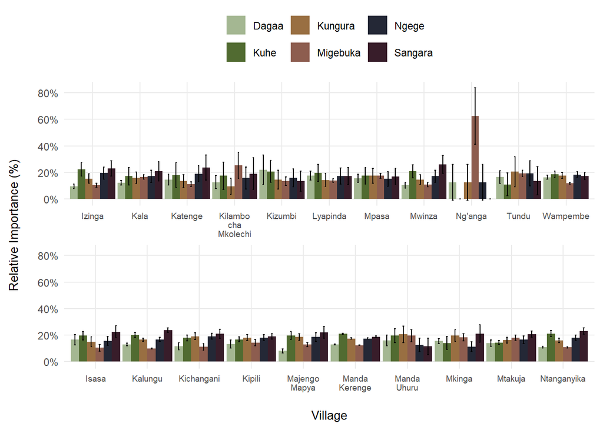

Figure 5: Relative importance of different species at village level

## Living Conditions, Housing, and Energy Use

### Water Use

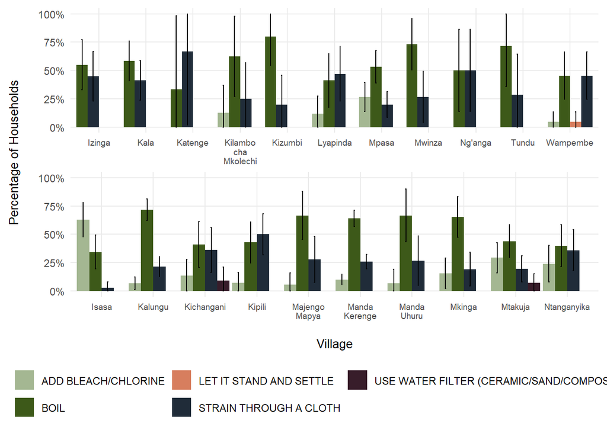

Figure 6: Main type of water treatment in the dry season

Table 3: Water treatment in the dry season at village level (%)

| Village | Add Bleach or Chlorine | Boil | Strain Through a Cloth | Use Water Filter | Let it Stand and Settle |
| --- | --- | --- | --- | --- | --- |
| Isasa | 62.9% | 34.3% | 2.9% |  |  |
| Izinga |  | 55% | 45% |  |  |
| Kala |  | 58.6% | 41.4% |  |  |
| Kalungu | 6.8% | 71.6% | 21.6% |  |  |
| Katenge |  | 33.3% | 66.7% |  |  |
| Kichangani | 13.6% | 40.9% | 36.4% | 9.1% |  |
| Kilambo cha Mkolechi | 12.5% | 62.5% | 25% |  |  |
| Kipili | 7.1% | 42.9% | 50% |  |  |
| Kizumbi |  | 80% | 20% |  |  |
| Lyapinda | 11.8% | 41.2% | 47.1% |  |  |
| Majengo Mapya | 5.6% | 66.7% | 27.8% |  |  |
| Manda Kerenge | 10.1% | 64% | 25.9% |  |  |
| Manda Uhuru | 6.7% | 66.7% | 26.7% |  |  |
| Mkinga | 15.4% | 65.4% | 19.2% |  |  |
| Mpasa | 26.7% | 53.3% | 20% |  |  |
| Mtakuja | 29.3% | 43.9% | 19.5% | 7.3% |  |
| Mwinza |  | 73.3% | 26.7% |  |  |
| Ng'anga |  | 50% | 50% |  |  |
| Ntanganyika | 24% | 40% | 36% |  |  |
| Tundu |  | 71.4% | 28.6% |  |  |
| Wampembe | 4.5% | 45.5% | 45.5% |  | 4.5% |

[figure not shown]

Figure 7: Main source of water in the dry season

Table 4: Main water source in the dry season at village level (%)

| Village | Neighbour's Open Well | Neighbour's Tap | Open Public Well | Piped into Plot | Pond or Lake | Protected Public Well | Protected Well in Plot | Public Tap | River or Stream | Spring | Neighbour's Borehole | Open Well | Water Vendor | Piped into Dwelling | Other |
| --- | --- | --- | --- | --- | --- | --- | --- | --- | --- | --- | --- | --- | --- | --- | --- |
| Isasa | 2.6% | 2.6% | 17.9% | 5.1% | 2.6% | 15.4% | 7.7% | 7.7% | 33.3% | 5.1% |  |  |  |  |  |
| Izinga |  |  | 7.3% |  | 7.3% | 38.2% |  |  | 45.5% | 1.8% |  |  |  |  |  |
| Kala |  |  |  |  | 5.3% |  |  |  | 94.7% |  |  |  |  |  |  |
| Kalungu |  |  | 17.2% |  | 10.3% | 13.8% | 1.1% | 12.6% | 31% | 13.8% |  |  |  |  |  |
| Katenge |  |  | 20% |  | 6.7% | 20% |  |  | 53.3% |  |  |  |  |  |  |
| Kichangani | 6.7% |  | 24.4% |  | 2.2% | 4.4% | 2.2% | 11.1% | 24.4% | 6.7% | 8.9% | 4.4% | 4.4% |  |  |
| Kilambo cha Mkolechi |  |  |  |  | 10.5% | 2.6% |  | 86.8% |  |  |  |  |  |  |  |
| Kipili | 1.8% | 1.8% |  | 3.6% | 12.5% | 8.9% |  | 66.1% | 1.8% | 1.8% |  |  |  | 1.8% |  |
| Kizumbi |  |  |  |  | 3.2% |  |  |  | 96.8% |  |  |  |  |  |  |
| Lyapinda |  |  | 40% |  | 4.6% | 7.7% |  |  | 38.5% | 9.2% |  |  |  |  |  |
| Majengo Mapya |  |  | 16.7% |  | 20% | 6.7% |  | 53.3% |  | 3.3% |  |  |  |  |  |
| Manda Kerenge |  |  |  |  | 93.5% |  |  |  | 2.8% |  |  |  | 2.8% |  | 0.9% |
| Manda Uhuru |  |  |  |  | 84.2% |  |  | 5.3% | 5.3% | 5.3% |  |  |  |  |  |
| Mkinga |  |  | 4.1% |  | 6.1% | 26.5% |  | 59.2% |  | 4.1% |  |  |  |  |  |
| Mpasa |  |  |  |  | 8% | 1.1% |  | 87.4% | 1.1% |  |  |  |  | 2.3% |  |
| Mtakuja | 2% | 2% | 2% |  | 12.2% | 6.1% | 2% | 8.2% | 32.7% | 8.2% | 4.1% | 6.1% | 4.1% | 10.2% |  |
| Mwinza |  |  |  |  | 2.6% |  |  |  | 97.4% |  |  |  |  |  |  |
| Ng'anga |  |  | 11.1% |  | 27.8% |  |  |  | 55.6% | 5.6% |  |  |  |  |  |
| Ntanganyika |  |  | 8.3% |  | 25% | 25% |  | 33.3% | 2.8% | 2.8% | 2.8% |  |  |  |  |
| Tundu |  |  |  |  | 3.1% | 6.2% |  | 53.1% | 37.5% |  |  |  |  |  |  |
| Wampembe | 0.9% |  | 50.4% |  | 2.7% | 22.1% |  | 21.2% | 0.9% | 0.9% |  |  | 0.9% |  |  |

### Sanitation

Table 5: Sanitation facilities at village level (%)

| Village | Shared Sanitation Facility | Flush elsewhere | Flush to pit latrine | No facility | Pit latrine with slab | Open pit | Composting toilet | VIP latrine | Other |
| --- | --- | --- | --- | --- | --- | --- | --- | --- | --- |
| Isasa | 17.9% | 7.7% | 69.2% | 2.6% | 5.1% | 15.4% |  |  |  |
| Izinga | 11.1% | 1.8% | 12.7% | 1.8% | 16.4% | 63.6% | 1.8% | 1.8% |  |
| Kala | 24.3% | 2.6% | 5.3% | 5.3% | 5.3% | 73.7% |  | 7.9% |  |
| Kalungu | 16.1% | 1.1% | 24.1% |  | 14.9% | 47.1% |  | 12.6% |  |
| Katenge | 6.7% |  | 6.7% |  | 20% | 73.3% |  |  |  |
| Kichangani | 22.2% | 15.6% | 31.1% | 2.2% | 4.4% | 24.4% |  | 22.2% |  |
| Kilambo cha Mkolechi | 26.3% |  | 26.3% |  | 2.6% | 63.2% |  | 7.9% |  |
| Kipili | 23.2% | 3.6% | 30.4% | 5.4% | 21.4% | 21.4% |  | 17.9% |  |
| Kizumbi | 12.9% |  | 6.5% |  | 25.8% | 58.1% |  | 9.7% |  |
| Lyapinda | 15.4% | 1.5% | 3.1% | 3.1% | 9.2% | 80% |  | 3.1% |  |
| Majengo Mapya | 31% |  | 6.7% | 3.3% | 20% | 63.3% |  | 6.7% |  |
| Manda Kerenge | 15.7% | 2.8% | 19.4% | 0.9% | 18.5% | 43.5% |  | 13% | 1.9% |
| Manda Uhuru | 33.3% |  | 5.3% | 15.8% | 26.3% | 52.6% |  |  |  |
| Mkinga | 18.4% |  | 18.4% | 2% | 6.1% | 65.3% |  | 8.2% |  |
| Mpasa | 23% | 3.4% | 5.7% |  | 11.5% | 75.9% |  | 3.4% |  |
| Mtakuja | 20.4% | 4.1% | 40.8% |  | 20.4% | 12.2% |  | 22.4% |  |
| Mwinza | 23.1% |  | 2.6% |  | 7.7% | 84.6% | 2.6% | 2.6% |  |
| Ng'anga | 33.3% |  |  |  | 16.7% | 83.3% |  |  |  |
| Ntanganyika | 41.7% | 2.8% | 41.7% | 2.8% | 13.9% | 36.1% |  | 2.8% |  |
| Tundu | 40.6% |  | 9.4% | 3.1% | 12.5% | 71.9% |  | 3.1% |  |
| Wampembe | 18.6% | 0.9% | 9.7% |  | 18.6% | 60.2% | 0.9% | 9.7% |  |

Table 6: Handwashing at village level (%)

| Village | Handwashing Place Available | Soap | Tippy Tap | Water |
| --- | --- | --- | --- | --- |
| Isasa | 48.7% | 27.8% | 19.4% | 52.8% |
| Izinga | 14.5% | 46.7% |  | 53.3% |
| Kala | 5.3% | 33.3% |  | 66.7% |
| Kalungu | 56.3% | 44.2% | 10.6% | 45.2% |
| Katenge | 20% | 40% |  | 60% |
| Kichangani | 22.2% | 43.8% | 6.2% | 50% |
| Kilambo cha Mkolechi | 23.7% | 42.1% | 21.1% | 36.8% |
| Kipili | 23.2% | 36.4% | 4.5% | 59.1% |
| Kizumbi | 19.4% | 46.2% | 7.7% | 46.2% |
| Lyapinda | 9.2% | 37.5% |  | 62.5% |
| Majengo Mapya | 36.7% | 30.4% | 26.1% | 43.5% |
| Manda Kerenge | 25% | 43.6% | 12.7% | 43.6% |
| Manda Uhuru | 36.8% | 41.7% |  | 58.3% |
| Mkinga | 36.7% | 48.6% |  | 51.4% |
| Mpasa | 28.2% | 37.2% | 9.3% | 53.5% |
| Mtakuja | 51% | 43.2% | 2.3% | 54.5% |
| Mwinza | 12.8% | 33.3% | 11.1% | 55.6% |
| Ng'anga | 11.1% |  |  | 100% |
| Ntanganyika | 41.7% | 41.7% | 12.5% | 45.8% |
| Tundu | 28.1% | 25% | 8.3% | 66.7% |
| Wampembe | 9.7% | 45% | 5% | 50% |

## Household Items

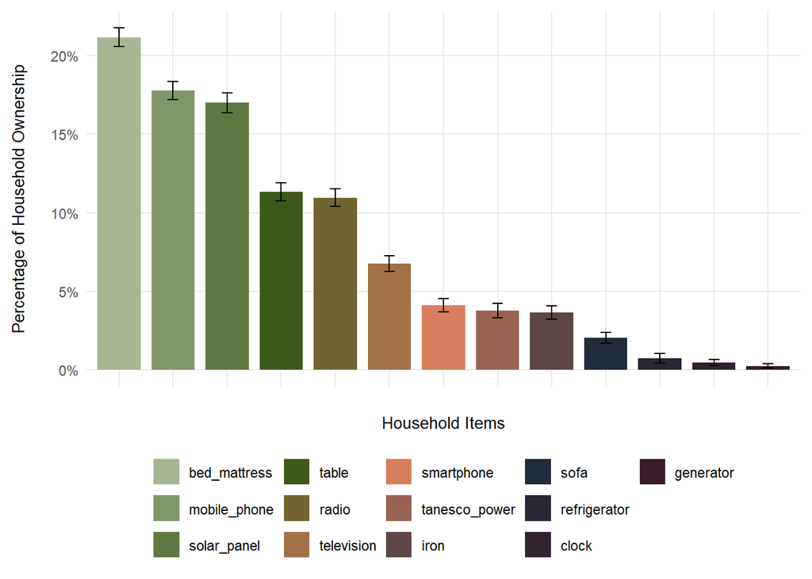

Figure 8: Household item ownership

Table 7: Asset ownership at village level (%)

| Village | Bed or Mattress | Clock | Generator | Iron | Mobile Phone | Radio | Refrigerator | Smartphone | Sofa | Solar Panel | Table | TANESCO Power | TV |
| --- | --- | --- | --- | --- | --- | --- | --- | --- | --- | --- | --- | --- | --- |
| Isasa | 17.3% | 0.9% | 0.9% | 7.7% | 15.9% | 10% | 1.4% | 6.8% | 1.4% | 7.3% | 10% | 10% | 10.5% |
| Izinga | 26.3% | 1% | 0.5% | 1.4% | 19.6% | 12% | 0.5% | 1.9% | 0.5% | 21.5% | 10% |  | 4.8% |
| Kala | 22.8% | 0.7% |  | 3.7% | 20.6% | 11.8% |  |  | 1.5% | 22.8% | 11.8% |  | 4.4% |
| Kalungu | 19% | 0.9% | 0.5% | 3.3% | 16.2% | 10.8% | 0.7% | 4.7% | 1.6% | 16.2% | 13.4% | 3.5% | 9.2% |
| Katenge | 32.6% |  |  |  | 23.9% | 8.7% |  | 2.2% |  | 13% | 15.2% | 2.2% | 2.2% |
| Kichangani | 16.8% | 1.6% |  | 6.8% | 15.2% | 7.6% | 1.2% | 5.2% | 2.4% | 12% | 14% | 8.4% | 8.8% |
| Kilambo cha Mkolechi | 21% |  | 1.2% | 4.2% | 17.4% | 13.2% |  | 4.2% |  | 18.6% | 12% |  | 8.4% |
| Kipili | 19.8% | 0.7% | 0.4% | 3.2% | 15.9% | 9.5% | 1.1% | 4.6% | 2.8% | 11.3% | 12% | 10.2% | 8.5% |
| Kizumbi | 23.3% |  |  | 4.3% | 19% | 13.8% | 0.9% | 0.9% |  | 22.4% | 7.8% | 2.6% | 5.2% |
| Lyapinda | 24.4% | 0.5% |  | 1.9% | 18.3% | 15% |  | 2.8% | 0.9% | 21.6% | 10.8% |  | 3.8% |
| Majengo Mapya | 26.9% |  |  | 0.9% | 23.1% | 10.2% |  | 2.8% |  | 22.2% | 8.3% | 1.9% | 3.7% |
| Manda Kerenge | 19.6% |  |  | 2.8% | 15.6% | 10.3% | 1.2% | 7.1% | 3% | 15.6% | 13.2% | 4.5% | 7.1% |
| Manda Uhuru | 22.2% |  |  | 2.5% | 17.3% | 9.9% |  | 4.9% | 2.5% | 19.8% | 12.3% |  | 8.6% |
| Mkinga | 21% | 0.5% |  | 2.5% | 18.5% | 10% |  | 2.5% | 3% | 18% | 11.5% | 2.5% | 10% |
| Mpasa | 21.4% |  | 0.3% | 4.5% | 18.5% | 12.1% | 0.3% | 4% | 1.8% | 19.3% | 10.3% | 1.3% | 6.3% |
| Mtakuja | 15.3% | 1% | 0.3% | 7.5% | 14.3% | 9.4% | 1.9% | 5.5% | 5.2% | 8.4% | 12% | 10.7% | 8.4% |
| Mwinza | 27.8% |  |  | 3.2% | 20.6% | 10.3% |  | 2.4% |  | 24.6% | 9.5% |  | 1.6% |
| Ng'anga | 27.9% |  |  |  | 21.3% | 8.2% |  | 3.3% |  | 23% | 8.2% | 1.6% | 6.6% |
| Ntanganyika | 18.7% | 0.5% |  | 4.9% | 15.9% | 12.1% | 0.5% | 6.6% | 2.7% | 13.2% | 12.1% | 4.4% | 8.2% |
| Tundu | 26.3% |  |  |  | 22.2% | 11.1% |  | 2% |  | 25.3% | 11.1% |  | 2% |
| Wampembe | 20.4% | 0.4% | 0.4% | 3.3% | 18.5% | 10.7% | 1.6% | 4.1% | 3.7% | 16.3% | 10.1% | 4.5% | 6% |

## Access to Credit

Proportion of households that borrowed money in the last year at village level

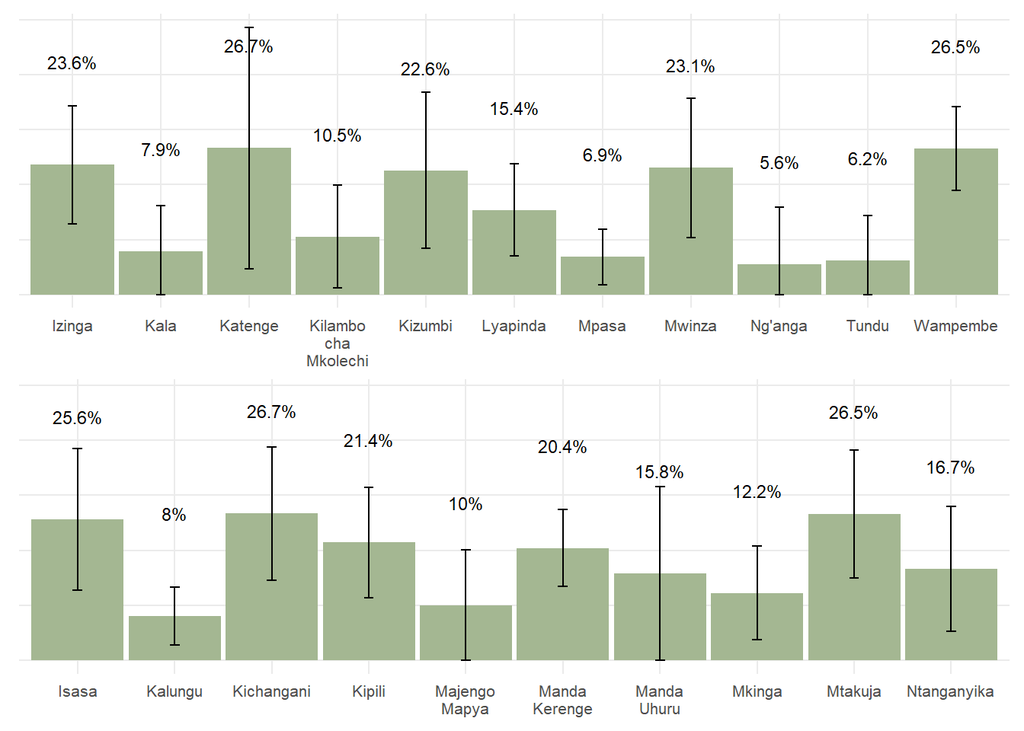

Figure 9: Proportion of households that borrowed money in the last year at village level

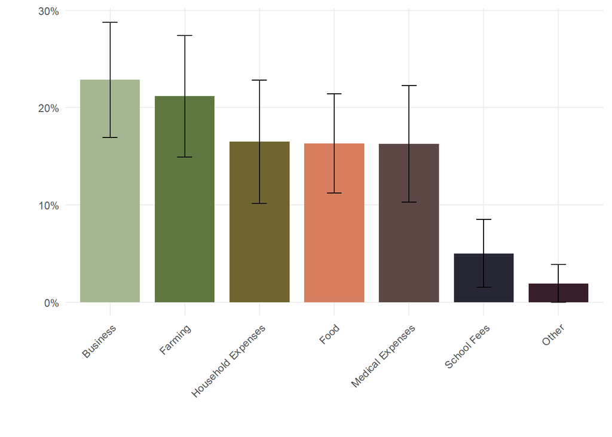

Figure 10: Purpose of the loan

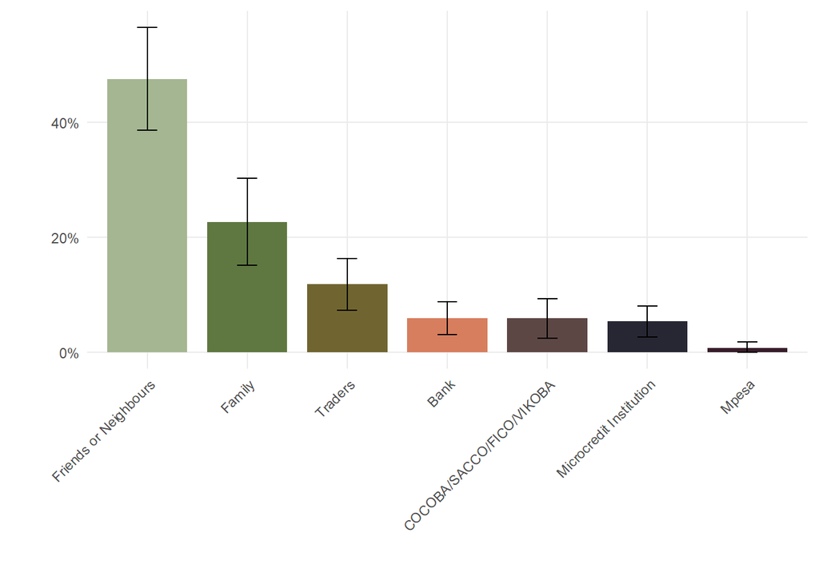

Figure 11: Source of loans

Reason for not having borrowed any money in the previous year

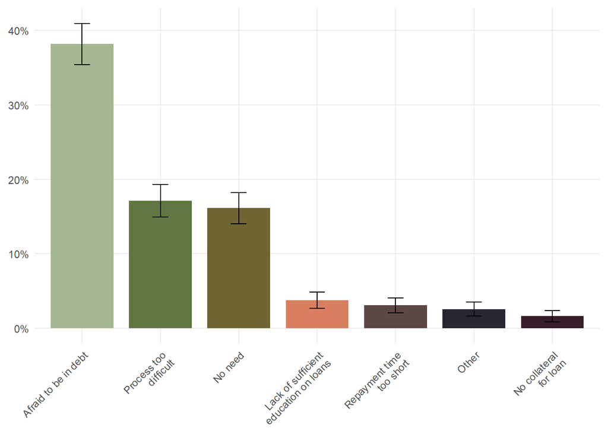

Figure 12: Reason for not having borrowed any money in the previous year

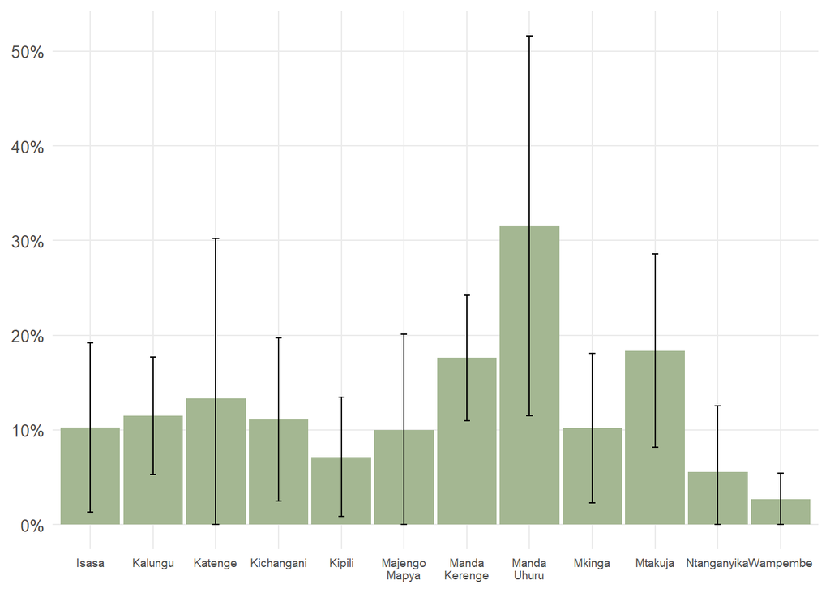

Figure 13: Household membership of a COCOBA, SACCO, or FICO at village level (%)

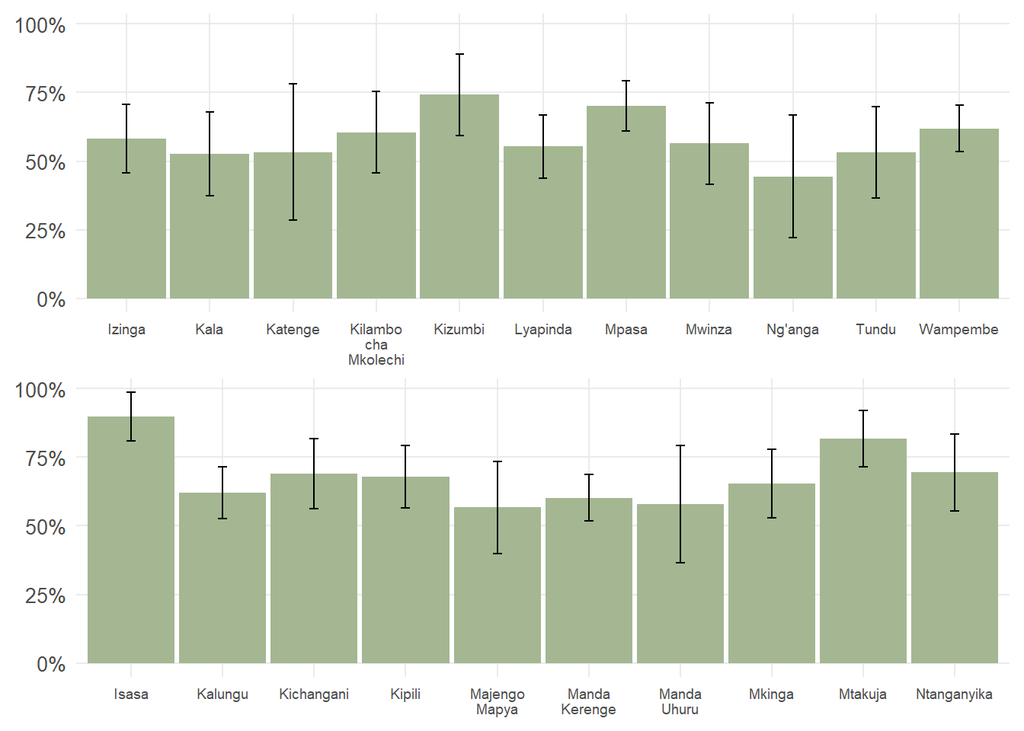

Figure 14: Mobile phone usage for financial transactions at village level (%)

## Beach Management Units (BMU)

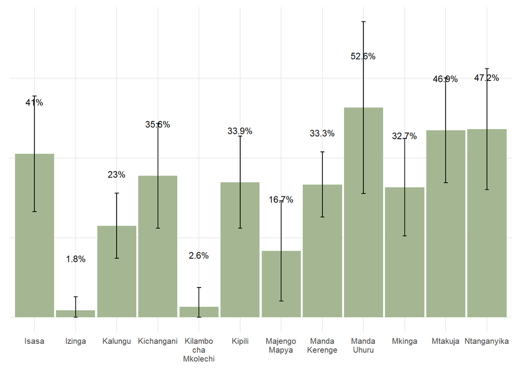

Figure 15: Household participation in BMU activities over the past 12 months at village level (%)

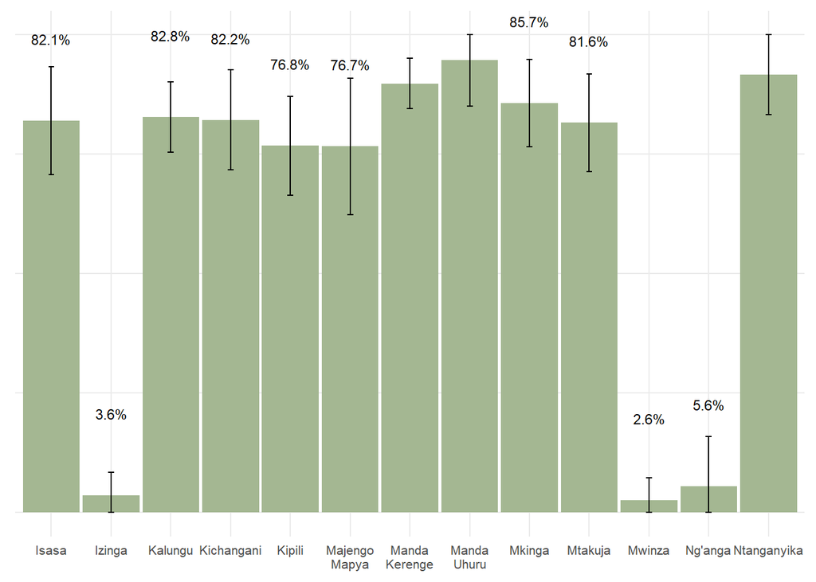

Figure 16: Household awareness of BMUs at village level (%)

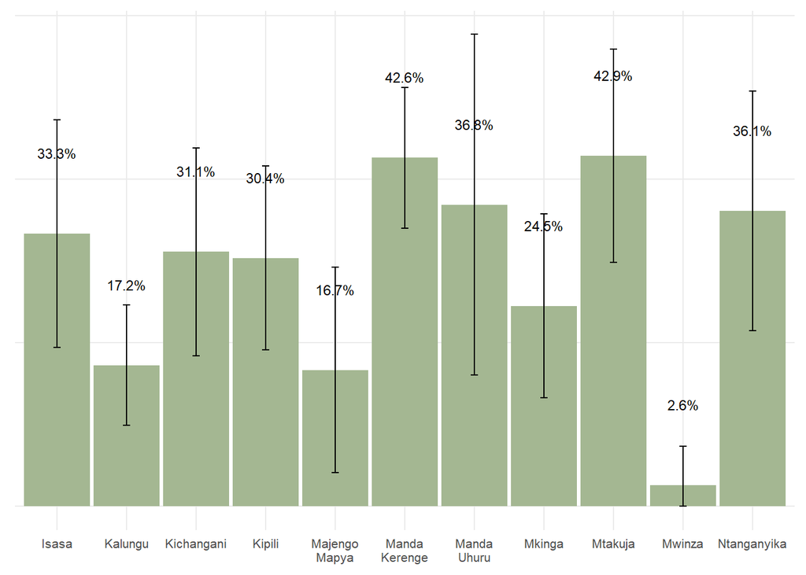

Figure 17: BMU membership at village level (%)

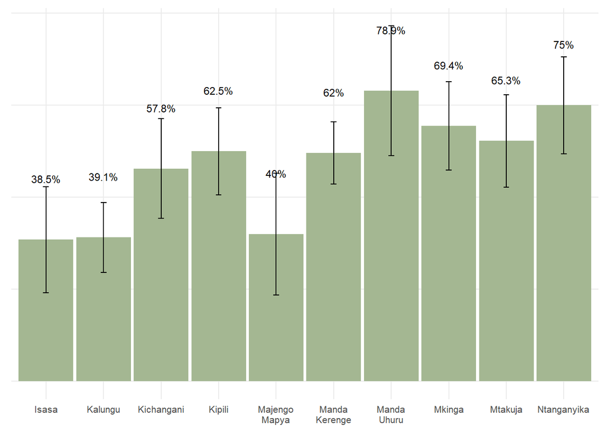

Table 8: BMU awareness and participation at village level (%)

[output not shown]

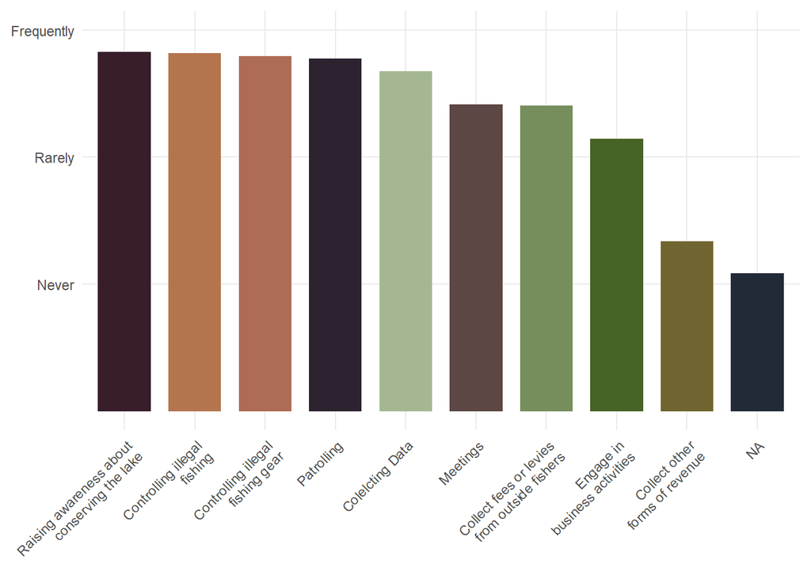

Figure 19: An indication of frequency for BMU activities

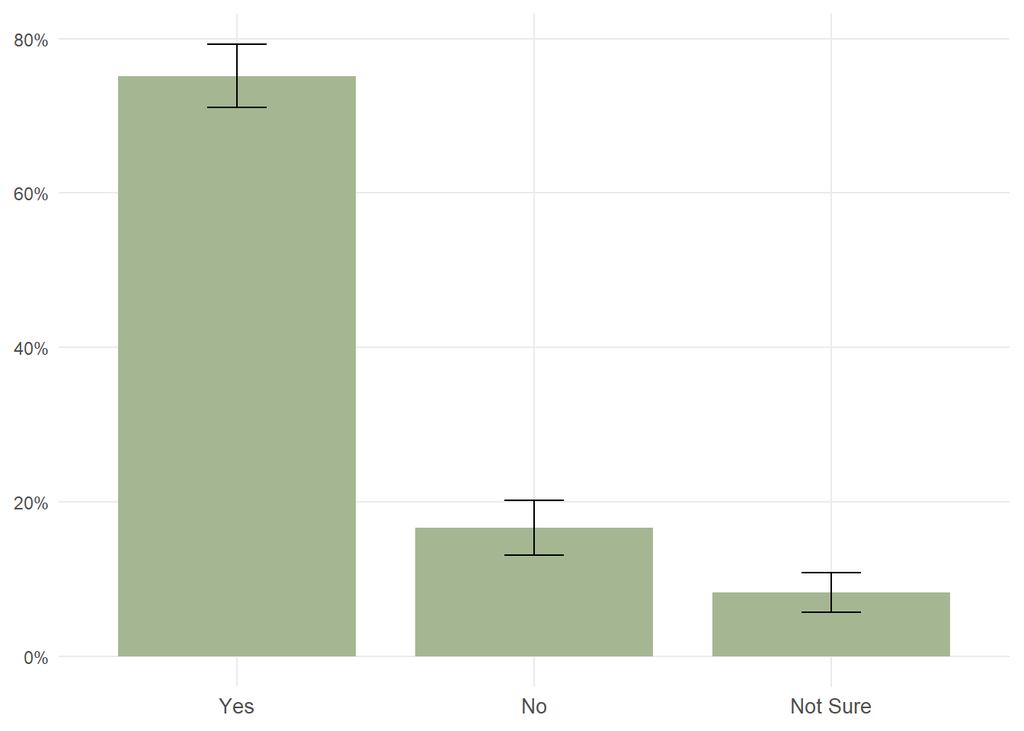

Figure 20: Do you think the BMU has good leaders?

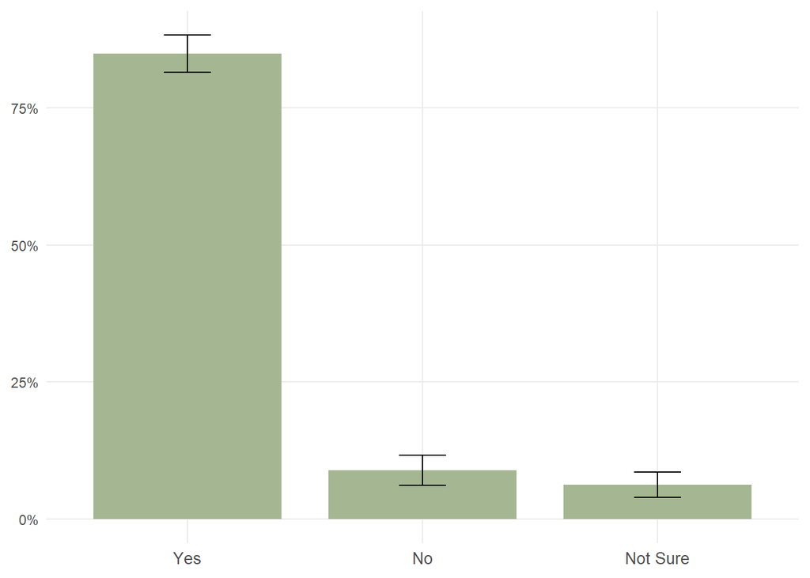

Figure 21: Were BMU leaders elected or chosen fairly?

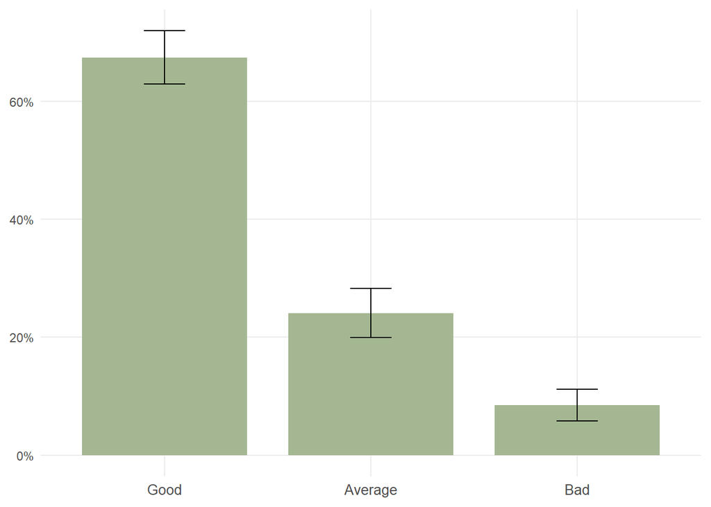

Table 9: Conflict of interest and/or power struggle between village leaders and BMU (%)

| Village | Conflicts of interest indicated | Go to ward or district government | Negotiate with each other | Go to village government | Do nothing |
| --- | --- | --- | --- | --- | --- |
| Isasa | 16.7% | 20% | 80% |  |  |
| Izinga | 100% |  | 100% |  |  |
| Kalungu | 21.2% | 14.3% | 28.6% | 21.4% | 21.4% |
| Kichangani | 44% | 25% | 33.3% | 16.7% | 16.7% |
| Kipili | 13.9% |  | 20% | 40% | 40% |
| Majengo Mapya | 13.3% |  |  | 50% |  |
| Manda Kerenge | 18.2% |  | 60% | 20% | 6.7% |
| Manda Uhuru | 20% | 33.3% | 33.3% | 33.3% |  |
| Mkinga | 23.5% |  | 70% | 10% | 20% |
| Mtakuja | 38.9% |  | 53.3% |  | 33.3% |
| Mwinza | 100% |  |  |  |  |
| Ng'anga |  |  |  |  |  |
| Ntanganyika | 34.5% | 15.4% | 30.8% | 23.1% | 30.8% |

## Fishers

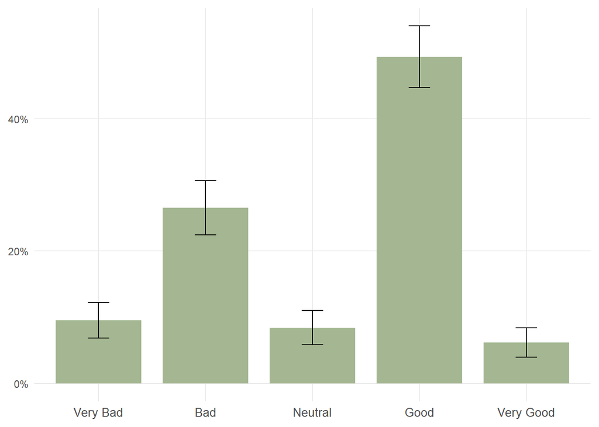

Figure 23: Self-assessment of fisheries resource management over the past five years

Table 10: Access rights, security, and decision making around fisheries resources at village level (%)

| Village | Rights to access and use fishery resources are being upheld by regulatory and/or communal systems | Happy with the current security of your rights over fisheries resources | Involved in decision-making processes regarding fisheries resources |
| --- | --- | --- | --- |
| Isasa | 70% | 60% | 40% |
| Izinga | 46.2% | 53.8% | 11.5% |
| Kala | 71.4% | 64.3% | 7.1% |
| Kalungu | 51.4% | 72.2% | 30.6% |
| Katenge | 42.9% | 42.9% | 14.3% |
| Kichangani | 60% | 80% | 40% |
| Kilambo cha Mkolechi | 69.2% | 64.3% | 35.7% |
| Kipili | 64.3% | 64.3% | 50% |
| Kizumbi | 50% | 66.7% | 10% |
| Lyapinda | 75% | 60.7% | 7.1% |
| Majengo Mapya | 53.8% | 69.2% |  |
| Manda Kerenge | 67.8% | 66.1% | 40.7% |
| Manda Uhuru | 55.6% | 44.4% | 44.4% |
| Mkinga | 100% | 100% | 45.5% |
| Mpasa | 42.4% | 57.6% | 15.2% |
| Mtakuja | 40% | 60% | 40% |
| Mwinza | 66.7% | 60% | 20% |
| Ng'anga | 20% | 40% |  |
| Ntanganyika | 64.3% | 50% | 42.9% |
| Tundu | 45.5% | 54.5% |  |
| Wampembe | 48.9% | 55.6% | 17.8% |

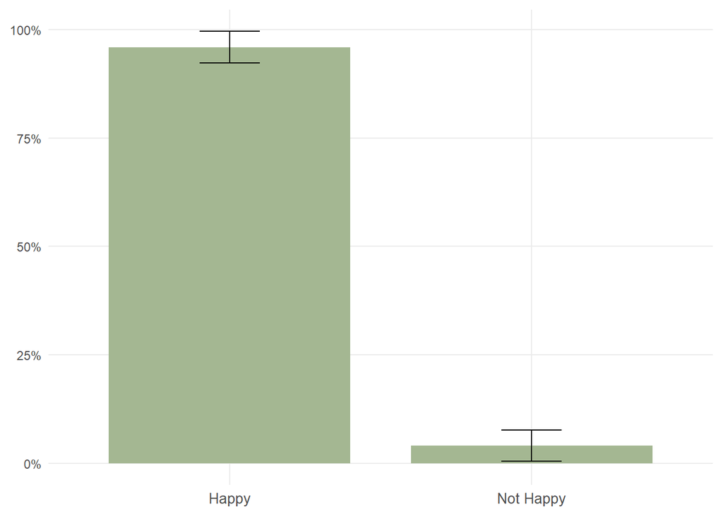

Figure 24: Satisfaction with involvement in decision-making around fisheries resources?

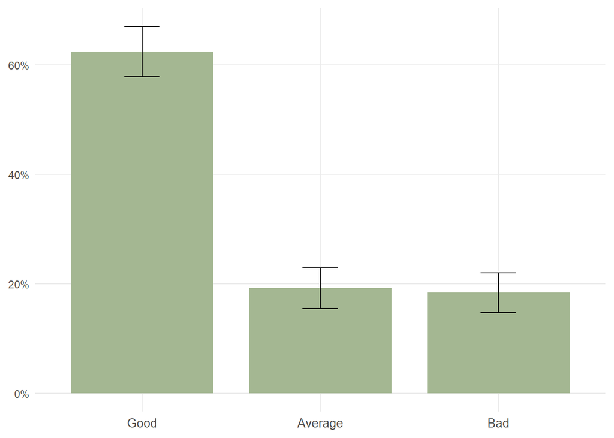

Figure 25: An indication of the relationship with fisheries extension officers

Table 11: Awareness and acceptance of fish reserves at village level (%)

| Village | Aware of fish reserves | Aware of fish reserve purpose | Think fish reserves are a good idea |
| --- | --- | --- | --- |
| Isasa | 100% | 100% | 80% |
| Izinga | 73.1% | 57.7% | 86.4% |
| Kala | 100% | 100% | 92.9% |
| Kalungu | 83.3% | 91.2% | 90.6% |
| Katenge | 57.1% | 42.9% | 50% |
| Kichangani | 100% | 90% | 100% |
| Kilambo cha Mkolechi | 85.7% | 92.9% | 100% |
| Kipili | 92.9% | 100% | 92.9% |
| Kizumbi | 60% | 80% | 80% |
| Lyapinda | 78.6% | 77.8% | 92.9% |
| Majengo Mapya | 92.3% | 100% | 100% |
| Manda Kerenge | 94.9% | 89.7% | 91.2% |
| Manda Uhuru | 100% | 88.9% | 100% |
| Mkinga | 100% | 100% | 100% |
| Mpasa | 93.9% | 93.9% | 87.9% |
| Mtakuja | 93.3% | 100% | 93.3% |
| Mwinza | 73.3% | 60% | 78.6% |
| Ng'anga | 20% | 40% | 66.7% |
| Ntanganyika | 92.3% | 100% | 92.9% |
| Tundu | 40% | 70% | 77.8% |
| Wampembe | 77.8% | 77.8% | 83.7% |

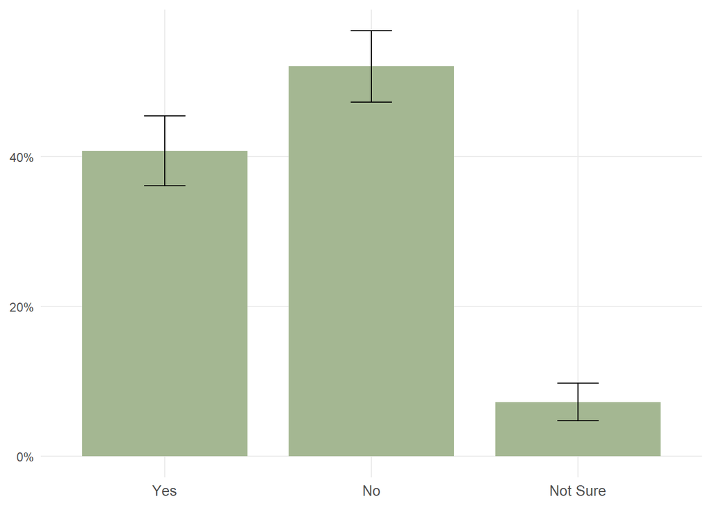

Figure 26: At the moment, do you think the current number of fish in the lake is sufficient to meet the fishing, food, and livelihood needs of the community?

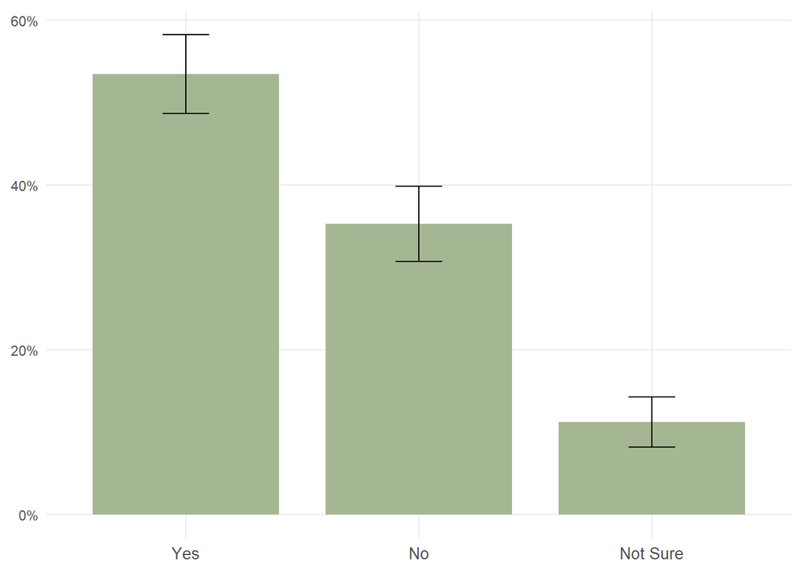

Figure 27: In the future, do you think there will be sufficient fish for the communities

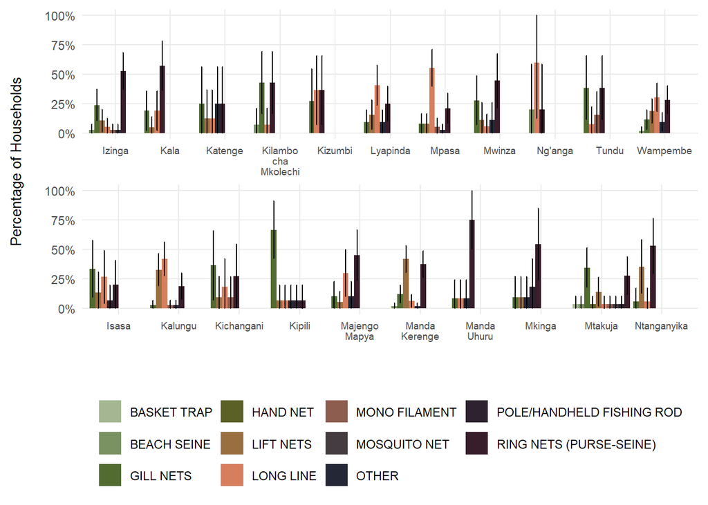

Figure 28: Type of fishing gear used at village level (%)

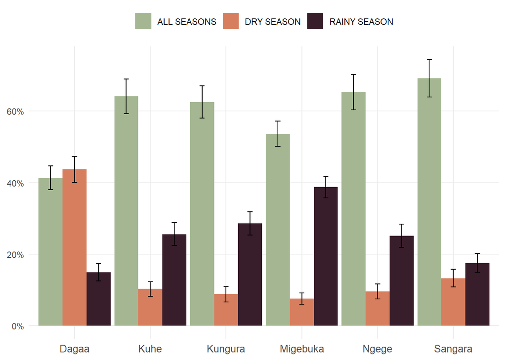

Figure 29: Seasonal targeting of fish species over the past five years

| village | Less than 2 hrs | Less than 6 hrs | Less than 10 hrs | More than 10 hrs | Mean time (hrs) |
| --- | --- | --- | --- | --- | --- |
| Isasa | 20% | 60% | 20% | 0% | 03:28:00 |
| Izinga | 38.5% | 61.5% | 0% | 0% | 02:05:00 |
| Kala | 21.4% | 71.4% | 0% | 7.1% | 03:57:00 |
| Kalungu | 8.3% | 91.7% | 0% | 0% | 02:56:00 |
| Katenge | 28.6% | 71.4% | 0% | 0% | 02:30:00 |
| Kichangani | 20% | 70% | 0% | 10% | 03:42:00 |
| Kilambo cha Mkolechi | 28.6% | 71.4% | 0% | 0% | 02:16:00 |
| Kipili | 42.9% | 50% | 0% | 7.1% | 02:26:00 |
| Kizumbi | 50% | 50% | 0% | 0% | 02:08:00 |
| Lyapinda | 17.9% | 78.6% | 3.6% | 0% | 02:53:00 |
| Majengo Mapya | 23.1% | 76.9% | 0% | 0% | 02:46:00 |
| Manda Kerenge | 33.9% | 57.6% | 1.7% | 6.8% | 02:52:00 |
| Manda Uhuru | 44.4% | 55.6% | 0% | 0% | 01:55:00 |
| Mkinga | 45.5% | 45.5% | 0% | 9.1% | 03:30:00 |
| Mpasa | 21.2% | 78.8% | 0% | 0% | 02:31:00 |
| Mtakuja | 20% | 80% | 0% | 0% | 02:50:00 |
| Mwinza | 26.7% | 73.3% | 0% | 0% | 02:25:00 |
| Ng'anga | 40% | 60% | 0% | 0% | 02:24:00 |
| Ntanganyika | 21.4% | 71.4% | 0% | 7.1% | 03:36:00 |
| Tundu | 36.4% | 63.6% | 0% | 0% | 02:30:00 |
| Wampembe | 33.3% | 66.7% | 0% | 0% | 02:13:00 |

| Response | Change in time needed to get to grounds compared to 5 years ago (%) | Change in average catch per trip compared to 5 years ago (%) |
| --- | --- | --- |
| Decreased | 29.6% | 66.7% |
| Increased | 29% | 15% |
| Not Sure | 1.8% | 1.4% |
| No Change | 39.6% | 17% |

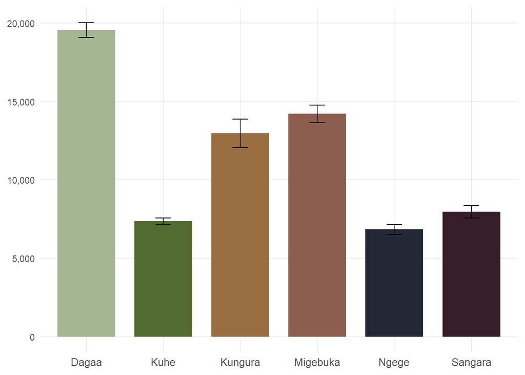

Figure 30: Highest sale prices (TSh) of fish species over the past five years